# Homework 6: Applied Machine Learning

Josh Gregory

## Canvas assignment instructions

The homework for HW 6, use the roadmap for building machine learning systems and the sklearn library, train a kNN algorithm. For full credit, perfrom EDA steps and steps to build model in sklearn (step 1 - 6 cleary marked and annotated ) in your .ipynb. Combine transformers and estimators in a pipeline. Produce a confusion matrix, test and training accuracy, and Roc_Auc training score. What can you conclude from the confusion matrix. Produce a ROC/AUC graph. Produce Accuracy, Precision, Recall and F1 scores.

```python
from IPython.display import Image
%matplotlib inline

#importing the necessary libraries
import pandas as pd
import matplotlib.pyplot as plt
import numpy as np
from sklearn.model_selection import train_test_split, cross_val_score, cross_val_predict
from sklearn.tree import DecisionTreeClassifier
from sklearn.neighbors import KNeighborsClassifier
from sklearn.pipeline import make_pipeline
from sklearn.pipeline import make_pipeline
from sklearn.metrics import classification_report, accuracy_score, confusion_matrix
from sklearn.preprocessing import StandardScaler
from sklearn import tree, preprocessing
import seaborn as sns
sns.set()
```

```python
from matplotlib.colors import ListedColormap
import matplotlib.pyplot as plt

# To check recent matplotlib compatibility
import matplotlib
from distutils.version import LooseVersion


def plot_decision_regions(X, y, classifier, test_idx=None, resolution=0.02):

    # setup marker generator and color map
    markers = ('s', 'x', 'o', '^', 'v')
    colors = ('red', 'blue', 'lightgreen', 'gray', 'cyan')
    cmap = ListedColormap(colors[:len(np.unique(y))])

    # plot the decision surface
    x1_min, x1_max = X[:, 0].min() - 1, X[:, 0].max() + 1
    x2_min, x2_max = X[:, 1].min() - 1, X[:, 1].max() + 1
    xx1, xx2 = np.meshgrid(np.arange(x1_min, x1_max, resolution),
                           np.arange(x2_min, x2_max, resolution))
    Z = classifier.predict(np.array([xx1.ravel(), xx2.ravel()]).T)
    Z = Z.reshape(xx1.shape)
    plt.contourf(xx1, xx2, Z, alpha=0.3, cmap=cmap)
    plt.xlim(xx1.min(), xx1.max())
    plt.ylim(xx2.min(), xx2.max())

    for idx, cl in enumerate(np.unique(y)):
        plt.scatter(x=X[y == cl, 0],
                    y=X[y == cl, 1],
                    alpha=0.8,
                    color=colors[idx],
                    marker=markers[idx],
                    label=cl,
                    edgecolor='black')

    # highlight test examples
    if test_idx:
        # plot all examples
        X_test, y_test = X[test_idx, :], y[test_idx]


        if LooseVersion(matplotlib.__version__) < LooseVersion('0.3.4'):
            plt.scatter(X_test[:, 0],
                        X_test[:, 1],
                        c='',
                        edgecolor='black',
                        alpha=1.0,
                        linewidth=1,
                        marker='o',
                        s=100,
                        label='test set')
        else:
            plt.scatter(X_test[:, 0],
                        X_test[:, 1],
                        c='none',
                        edgecolor='black',
                        alpha=1.0,
                        linewidth=1,
                        marker='o',
                        s=100,
                        label='test set')
```

## Perform EDA according to ICHW 1

### 1. Find the different classes, number of classes, and the number of samples within each class from ICHW1/HW1

```python
data = pd.read_csv('cancer.csv')

data
```

|  | id | diagnosis | radius_mean | texture_mean | perimeter_mean | area_mean | smoothness_mean | compactness_mean | concavity_mean | concave points_mean | symmetry_mean | fractal_dimension_mean |
| --- | --- | --- | --- | --- | --- | --- | --- | --- | --- | --- | --- | --- |
| 0 | 842302 | M | 17.99 | 10.38 | 122.80 | 1001.0 | 0.11840 | 0.27760 | 0.30010 | 0.14710 | 0.2419 | 0.07871 |
| 1 | 842517 | M | 20.57 | 17.77 | 132.90 | 1326.0 | 0.08474 | 0.07864 | 0.08690 | 0.07017 | 0.1812 | 0.05667 |
| 2 | 84300903 | M | 19.69 | 21.25 | 130.00 | 1203.0 | 0.10960 | 0.15990 | 0.19740 | 0.12790 | 0.2069 | 0.05999 |
| 3 | 84348301 | M | 11.42 | 20.38 | 77.58 | 386.1 | 0.14250 | 0.28390 | 0.24140 | 0.10520 | 0.2597 | 0.09744 |
| 4 | 84358402 | M | 20.29 | 14.34 | 135.10 | 1297.0 | 0.10030 | 0.13280 | 0.19800 | 0.10430 | 0.1809 | 0.05883 |
| ... | ... | ... | ... | ... | ... | ... | ... | ... | ... | ... | ... | ... |
| 564 | 926424 | M | 21.56 | 22.39 | 142.00 | 1479.0 | 0.11100 | 0.11590 | 0.24390 | 0.13890 | 0.1726 | 0.05623 |
| 565 | 926682 | M | 20.13 | 28.25 | 131.20 | 1261.0 | 0.09780 | 0.10340 | 0.14400 | 0.09791 | 0.1752 | 0.05533 |
| 566 | 926954 | M | 16.60 | 28.08 | 108.30 | 858.1 | 0.08455 | 0.10230 | 0.09251 | 0.05302 | 0.1590 | 0.05648 |
| 567 | 927241 | M | 20.60 | 29.33 | 140.10 | 1265.0 | 0.11780 | 0.27700 | 0.35140 | 0.15200 | 0.2397 | 0.07016 |
| 568 | 92751 | B | 7.76 | 24.54 | 47.92 | 181.0 | 0.05263 | 0.04362 | 0.00000 | 0.00000 | 0.1587 | 0.05884 |

569 rows × 12 columns

```python
classes = pd.unique(data['diagnosis'])
num_classes = len(classes)
each_class = data['diagnosis'].value_counts()

print(classes)
print(num_classes)
print(each_class)

print(data.info())
```

```
['M' 'B']
2
B    357
M    212
Name: diagnosis, dtype: int64
<class 'pandas.core.frame.DataFrame'>
RangeIndex: 569 entries, 0 to 568
Data columns (total 12 columns):
 #   Column                  Non-Null Count  Dtype
---  ------                  --------------  -----
 0   id                      569 non-null    int64
 1   diagnosis               569 non-null    object
 2   radius_mean             569 non-null    float64
 3   texture_mean            569 non-null    float64
 4   perimeter_mean          569 non-null    float64
 5   area_mean               569 non-null    float64
 6   smoothness_mean         569 non-null    float64
 7   compactness_mean        569 non-null    float64
 8   concavity_mean          569 non-null    float64
 9   concave points_mean     569 non-null    float64
 10  symmetry_mean           569 non-null    float64
 11  fractal_dimension_mean  569 non-null    float64
dtypes: float64(10), int64(1), object(1)
memory usage: 53.5+ KB
None
```

**What are the names of the features?** `radius_mean`, `texture_mean`, `perimeter_mean`, `area_mean`, `smoothness_mean`, `compactness_mean`, `concavity_mean`, `concave points_mean`, `symetry_mean`, and `fractal_dimension_mean`.

**What are the types of features?** All of the features are continuous.

**How many features do we have?** We have ten features total

**What are the classes?** We're told from the Canvas assignment sheet that the target is the second column, which I'm assuming is the diagnosis. We have two classes, `B` for a benign tumor, and `M` for a malignant tumor.

**How many classes do we have?** Two, see above for more details.

**How many samples of each class? are they balanced?** Benign: 357 Malignant: 212

Because some classes have more than others (more Benign samples than Malignant), these classes are not balanced.

### 2. Check missing values, outliers, and statistics

```python
data.isna().apply(pd.value_counts)
```

|  | id | diagnosis | radius_mean | texture_mean | perimeter_mean | area_mean | smoothness_mean | compactness_mean | concavity_mean | concave points_mean | symmetry_mean | fractal_dimension_mean |
| --- | --- | --- | --- | --- | --- | --- | --- | --- | --- | --- | --- | --- |
| False | 569 | 569 | 569 | 569 | 569 | 569 | 569 | 569 | 569 | 569 | 569 | 569 |

### Answers to questions

**Are there any missing values?** No. Since the previous line returned `False`, there are no values that are missing. Therefore, nothing needs to be done to get rid of outliers.

**Are there outliers?** Yes, in the boxplots below, we can see that there are outliers in every dataset. I'll let the scalers in the pipeline take care of this step

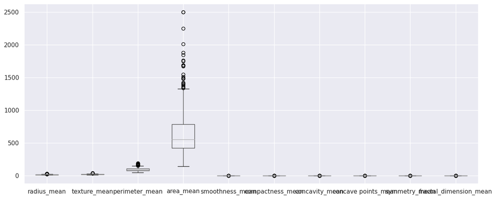

|  | count | mean | std | min | 25% | 50% | 75% | max |
| --- | --- | --- | --- | --- | --- | --- | --- | --- |
| id | 569.0 | 3.037183e+07 | 1.250206e+08 | 8670.00000 | 869218.00000 | 906024.00000 | 8.813129e+06 | 9.113205e+08 |
| radius_mean | 569.0 | 1.412729e+01 | 3.524049e+00 | 6.98100 | 11.70000 | 13.37000 | 1.578000e+01 | 2.811000e+01 |
| texture_mean | 569.0 | 1.928965e+01 | 4.301036e+00 | 9.71000 | 16.17000 | 18.84000 | 2.180000e+01 | 3.928000e+01 |
| perimeter_mean | 569.0 | 9.196903e+01 | 2.429898e+01 | 43.79000 | 75.17000 | 86.24000 | 1.041000e+02 | 1.885000e+02 |
| area_mean | 569.0 | 6.548891e+02 | 3.519141e+02 | 143.50000 | 420.30000 | 551.10000 | 7.827000e+02 | 2.501000e+03 |
| smoothness_mean | 569.0 | 9.636028e-02 | 1.406413e-02 | 0.05263 | 0.08637 | 0.09587 | 1.053000e-01 | 1.634000e-01 |
| compactness_mean | 569.0 | 1.043410e-01 | 5.281276e-02 | 0.01938 | 0.06492 | 0.09263 | 1.304000e-01 | 3.454000e-01 |
| concavity_mean | 569.0 | 8.879932e-02 | 7.971981e-02 | 0.00000 | 0.02956 | 0.06154 | 1.307000e-01 | 4.268000e-01 |
| concave points_mean | 569.0 | 4.891915e-02 | 3.880284e-02 | 0.00000 | 0.02031 | 0.03350 | 7.400000e-02 | 2.012000e-01 |
| symmetry_mean | 569.0 | 1.811619e-01 | 2.741428e-02 | 0.10600 | 0.16190 | 0.17920 | 1.957000e-01 | 3.040000e-01 |
| fractal_dimension_mean | 569.0 | 6.279761e-02 | 7.060363e-03 | 0.04996 | 0.05770 | 0.06154 | 6.612000e-02 | 9.744000e-02 |

```python
# Make a bocplot of every column except for the ID number and the diagnosis since those
# don't make sense to include in a boxplot.
data.iloc[:, 2:].boxplot(figsize = (15,6))
plt.show()
data.describe().T
```

`area_mean` is taking up a lot of space, so I'm going to make another boxplot without `area_mean` to try and get a better picture of the spread of the other features:

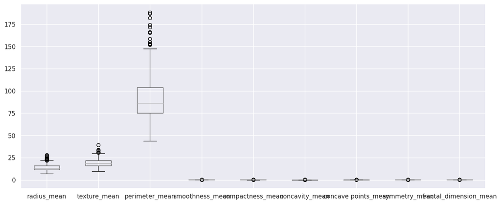

```python
df_filtered = data.drop(data.columns[[0, 1, 5]], axis=1)
df_filtered.boxplot(figsize = (15,6))
```

Changes to make to the dataset:

1. Change the "Diagnosis" column to the following:

"B": 0 "M": 1

2. Let the StandardScaler handle the outliers

```python
# Implementing step 1
diag_dict = {"B": 0, "M": 1}
data['diagnosis'] = data['diagnosis'].replace(diag_dict)
```

### Check distributions and correlations

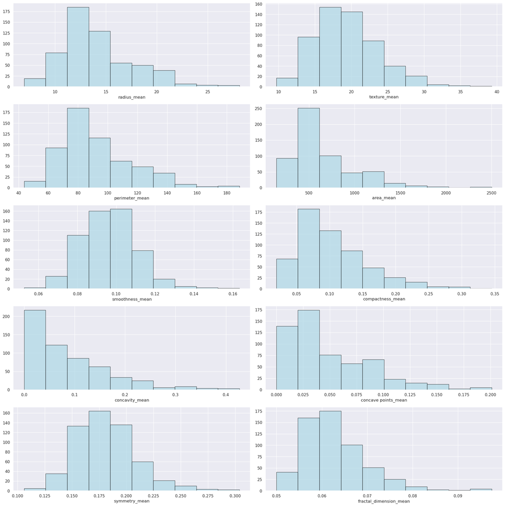

```python
# Select all columns except the first two
columns_to_plot = data.columns[2:]  # Skips the first two columns

plt.figure(figsize=(20, 20))

# Loop through each column and plot a histogram
for i, col in enumerate(columns_to_plot):
    plt.subplot(5, 2, i + 1)  # 5 rows, 2 columns, i + 1 to assign each plot a position
    plt.hist(data[col], color='lightblue', edgecolor='black', alpha=0.7)
    plt.xlabel(col)

plt.tight_layout()  # Adjust spacing between plots
plt.show()
```

**What kind of distributions do the features have?**

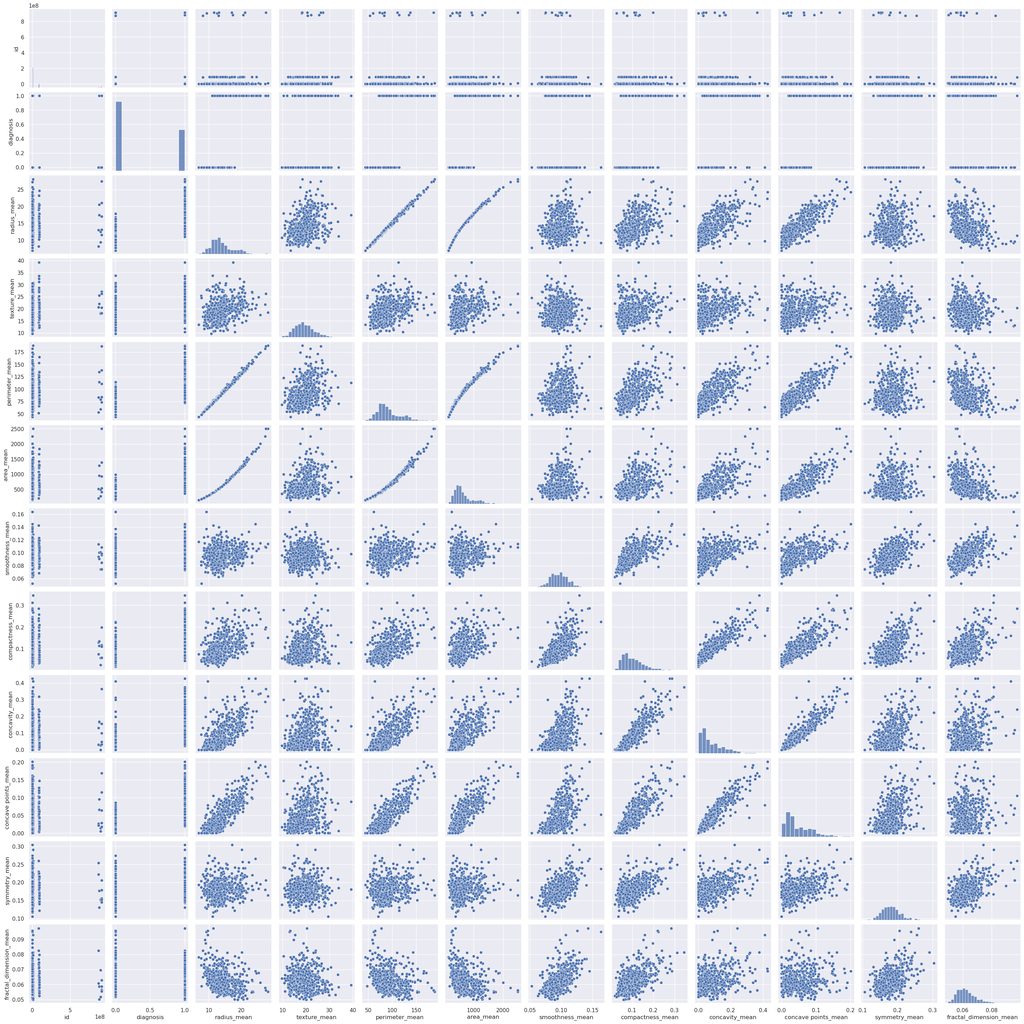

```python
sns.pairplot(data) # pairplot
plt.show()
```

**What kind of correlation does the data exhibit?**

```python
data.corr()
```

|  | id | diagnosis | radius_mean | texture_mean | perimeter_mean | area_mean | smoothness_mean | compactness_mean | concavity_mean | concave points_mean | symmetry_mean | fractal_dimension_mean |
| --- | --- | --- | --- | --- | --- | --- | --- | --- | --- | --- | --- | --- |
| id | 1.000000 | 0.039769 | 0.074626 | 0.099770 | 0.073159 | 0.096893 | -0.012968 | 0.000096 | 0.050080 | 0.044158 | -0.022114 | -0.052511 |
| diagnosis | 0.039769 | 1.000000 | 0.730029 | 0.415185 | 0.742636 | 0.708984 | 0.358560 | 0.596534 | 0.696360 | 0.776614 | 0.330499 | -0.012838 |
| radius_mean | 0.074626 | 0.730029 | 1.000000 | 0.323782 | 0.997855 | 0.987357 | 0.170581 | 0.506124 | 0.676764 | 0.822529 | 0.147741 | -0.311631 |
| texture_mean | 0.099770 | 0.415185 | 0.323782 | 1.000000 | 0.329533 | 0.321086 | -0.023389 | 0.236702 | 0.302418 | 0.293464 | 0.071401 | -0.076437 |
| perimeter_mean | 0.073159 | 0.742636 | 0.997855 | 0.329533 | 1.000000 | 0.986507 | 0.207278 | 0.556936 | 0.716136 | 0.850977 | 0.183027 | -0.261477 |
| area_mean | 0.096893 | 0.708984 | 0.987357 | 0.321086 | 0.986507 | 1.000000 | 0.177028 | 0.498502 | 0.685983 | 0.823269 | 0.151293 | -0.283110 |
| smoothness_mean | -0.012968 | 0.358560 | 0.170581 | -0.023389 | 0.207278 | 0.177028 | 1.000000 | 0.659123 | 0.521984 | 0.553695 | 0.557775 | 0.584792 |
| compactness_mean | 0.000096 | 0.596534 | 0.506124 | 0.236702 | 0.556936 | 0.498502 | 0.659123 | 1.000000 | 0.883121 | 0.831135 | 0.602641 | 0.565369 |
| concavity_mean | 0.050080 | 0.696360 | 0.676764 | 0.302418 | 0.716136 | 0.685983 | 0.521984 | 0.883121 | 1.000000 | 0.921391 | 0.500667 | 0.336783 |
| concave points_mean | 0.044158 | 0.776614 | 0.822529 | 0.293464 | 0.850977 | 0.823269 | 0.553695 | 0.831135 | 0.921391 | 1.000000 | 0.462497 | 0.166917 |
| symmetry_mean | -0.022114 | 0.330499 | 0.147741 | 0.071401 | 0.183027 | 0.151293 | 0.557775 | 0.602641 | 0.500667 | 0.462497 | 1.000000 | 0.479921 |
| fractal_dimension_mean | -0.052511 | -0.012838 | -0.311631 | -0.076437 | -0.261477 | -0.283110 | 0.584792 | 0.565369 | 0.336783 | 0.166917 | 0.479921 | 1.000000 |

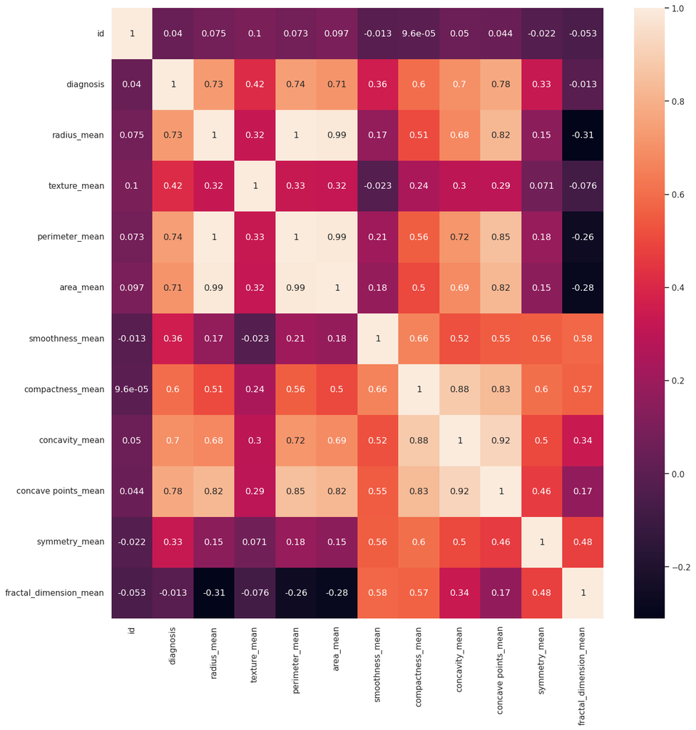

```python
plt.figure(figsize=(15, 15))
sns.heatmap(data.corr(), annot = True)
plt.show()
```

## kNN Model

I'm going to choose the two variables `compactness_mean` and `concavity_mean`, since the seem to be correlated with each other but are two independent variables (whereas `perimeter_mean` and `area_mean` are not since you can calculate one from the other).

```python
# 1. Arrange the data into featues and target arrays.

# extract compactness_mean (7) and concavity_mean (8)
X = data.iloc[:, [7, 8]].values
y = data.iloc[:, 1]

# print(X)
# print(y)

# print(df.columns)
```

```python
print(X.shape)
print(y.shape)
```

```
(569, 2)
(569,)
```

```python
# 2. Split data into a training set and test set
#    Splitting data into 70% training and 30% test data:

from sklearn.model_selection import train_test_split

X_train, X_test, y_train, y_test = train_test_split(
    X, y, test_size=0.3, random_state=1, stratify=y)
```

```python
print('Labels count in y:', np.bincount(y))
print('Labels count in y_train:', np.bincount(y_train))
print('Labels count in y_test:', np.bincount(y_test))

print(X_train.shape)
print(X_test.shape)
# print(X_train)
```

```
Labels count in y: [357 212]
Labels count in y_train: [250 148]
Labels count in y_test: [107  64]
(398, 2)
(171, 2)
```

```python
# 3. Select the ML algorithm, and its parameteters

from sklearn.preprocessing import StandardScaler
from sklearn.preprocessing import Normalizer
from sklearn.pipeline import make_pipeline
from sklearn.metrics import confusion_matrix
from sklearn.metrics import roc_auc_score

#scaler = StandardScaler()

#X_train_std = scaler.fit_transform(X_train)

#X_test_std = scaler.transform(X_test)

pipe_knn = make_pipeline(StandardScaler(),
                        KNeighborsClassifier(n_neighbors=7))

X_train, X_test, y_train, y_test = train_test_split(X, y, random_state=0)

pipe_knn.fit(X_train, y_train)
y_pred = pipe_knn.predict(X_test)

print('Test Accuracy: %.3f' % pipe_knn.score(X_test, y_test))
```

```
Test Accuracy: 0.874
```

```python
confmat = confusion_matrix(y_test, y_pred)

print(confmat)
print('Test Accuracy: %.3f' % pipe_knn.score(X_test, y_test))

training_score= cross_val_score(pipe_knn,X_train,y_train,cv=5)
print('Training accuracy score of {} is {}'.format("kNN",round(training_score.mean()*100,2)))
train_pred = cross_val_predict(pipe_knn, X_train, y_train, cv=5)
print('Roc_Auc training score for {} is {} '.format("kNN", round(roc_auc_score(y_train,train_pred)*100,2)))
```

```
[[79 11]
 [ 7 46]]
Test Accuracy: 0.874
Training accuracy score of kNN is 86.63
Roc_Auc training score for kNN is 85.38
```

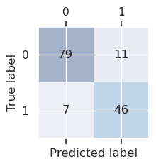

```python
import matplotlib.pyplot as plt

fig, ax = plt.subplots(figsize=(2.5, 2.5))
ax.matshow(confmat, cmap=plt.cm.Blues, alpha=0.3)
for i in range(confmat.shape[0]):
    for j in range(confmat.shape[1]):
        ax.text(x=j, y=i, s=confmat[i, j], va='center', ha='center')

plt.xlabel('Predicted label')
plt.ylabel('True label')

plt.tight_layout()
#plt.savefig('images/06_09.png', dpi=300)
plt.show()
```

```python
confmat = confusion_matrix(y_true=y_test, y_pred=y_pred, labels=[1, 0])
print(confmat)
```

```
[[46  7]
 [11 79]]
```

```
<sklearn.metrics._plot.confusion_matrix.ConfusionMatrixDisplay at 0x7f66888f5e10>
```

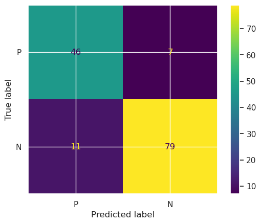

```python
from sklearn.metrics import confusion_matrix, ConfusionMatrixDisplay

#cm = confusion_matrix(y_true, y_preds, normalize='all')
cmd = ConfusionMatrixDisplay(confmat, display_labels=['P','N'])
cmd.plot()
```

## Receiver Operating Characteristics (ROC) Area Under the Curve (AUC)

```
X_train2:  [0.05642 0.02688]
train_prob:  [0.8 0.2]
train_fpr:  [0.         0.         0.03370787 0.08614232 0.12359551 0.31086142
 1.        ]
train_tpr:  [0.         0.5408805  0.72327044 0.89937107 0.93081761 1.
 1.        ]
train_thr:  [2.  1.  0.8 0.6 0.4 0.2 0. ]


test_fpr:  [0.         0.03333333 0.08888889 0.13333333 0.15555556 0.35555556
 1.        ]
test_tpr:  [0.         0.52830189 0.75471698 0.86792453 0.90566038 0.94339623
 1.        ]
test_thr:  [2.  1.  0.8 0.6 0.4 0.2 0. ]
```

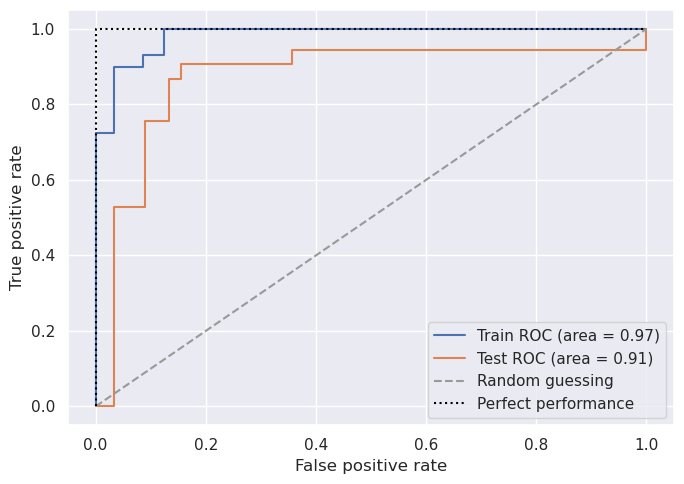

```python
from sklearn.metrics import roc_curve
from sklearn.metrics import auc

# smaller training set to make the curve more interesting
#X_train2 = X_train[:, [4, 14]]
#print(X_train[0,:])
#print(X_train2[0])
X_train2 = X_train[:, :]

pipe_knn = make_pipeline(StandardScaler(),
                         KNeighborsClassifier())


fig = plt.figure(figsize=(7, 5))


#############################################################
### TRAINING ROC CURVE
train_probas = pipe_knn.fit(X_train2,
                            y_train).predict_proba(X_train2)

fpr, tpr, thresholds = roc_curve(y_train,
                                 train_probas[:, 1],
                                 pos_label=1)

print("X_train2: ", X_train2[0])
print("train_prob: ", train_probas[0])
print("train_fpr: ", fpr)
print("train_tpr: ", tpr)
print("train_thr: ",thresholds)
print()
print()

roc_auc = auc(fpr, tpr)

plt.step(fpr,
         tpr,
         label='Train ROC (area = %0.2f)'
               % (roc_auc))
#############################################################


#############################################################
### TEST ROC CURVE
#test_probas = pipe_knn.predict_proba(X_test[:,[4, 14]])
test_probas = pipe_knn.predict_proba(X_test[:, :])

fpr, tpr, thresholds = roc_curve(y_test,
                                 test_probas[:, 1],
                                 pos_label=1)

print("test_fpr: ", fpr)
print("test_tpr: ", tpr)
print("test_thr: ",thresholds)

roc_auc = auc(fpr, tpr)

plt.step(fpr,
         tpr,
         where='post',
         label='Test ROC (area = %0.2f)'
               % (roc_auc))
#############################################################

plt.plot([0, 1],
         [0, 1],
         linestyle='--',
         color=(0.6, 0.6, 0.6),
         label='Random guessing')

plt.plot([0, 0, 1],
         [0, 1, 1],
         linestyle=':',
         color='black',
         label='Perfect performance')

plt.xlim([-0.05, 1.05])
plt.ylim([-0.05, 1.05])
plt.xlabel('False positive rate')
plt.ylabel('True positive rate')
plt.legend(loc="lower right")

plt.tight_layout()
plt.show()
```

## Accuracy, Precision, Recall and F1

```python
from sklearn.metrics import accuracy_score, precision_score, \
                            recall_score, f1_score

print('Accuracy: %.3f' % accuracy_score(y_true=y_test, y_pred=y_pred))
print('Precision: %.3f' % precision_score(y_true=y_test, y_pred=y_pred))
print('Recall: %.3f' % recall_score(y_true=y_test, y_pred=y_pred))
print('F1: %.3f' % f1_score(y_true=y_test, y_pred=y_pred))
```

```
Accuracy: 0.874
Precision: 0.807
Recall: 0.868
F1: 0.836
```

## Answer to question

**What can you conclude from the confusion matrix?**